# Question

In [Desmos graphing calculator](https://www.desmos.com/calculator), define $f(x)$ with the following parameterized equation, and add sliders for all three parameters ($a$, $h$, and $k$). The sliders should default with boundaries of $-10$ and $10$.

$$f(x)~=~a(x-h)^2+k$$

To make the animation shown below, two of the parameters were set to constants, and the other parameter was animated by pressing the “play” button. That animated parameter varies between $-10$ and $10$ by default.

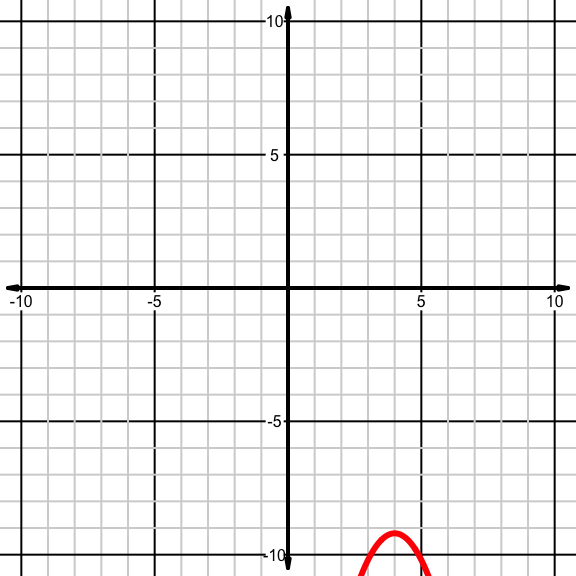

Find the value of each parameter, or if the parameter varies then choose “animated”.

- $a~=~$ ##ANSWER1##
- $h~=~$ ##ANSWER2##
- $k~=~$ ##ANSWER3##

## Answerlist

- animated
- -1
- 1
- animated
- -10
- -9
- -8
- -7
- -6
- -5
- -4
- -3
- -2
- -1
- 0
- 1
- 2
- 3
- 4
- 5
- 6
- 7
- 8
- 9
- 10
- animated
- -10
- -9
- -8
- -7
- -6
- -5
- -4
- -3
- -2
- -1
- 0
- 1
- 2
- 3
- 4
- 5
- 6
- 7
- 8
- 9
- 10

# Solution

- $a=$ -1
- $h=$ 4
- $k=$ animated

Try it out in Desmos!

# Meta-information

extype: cloze exclozetype: schoice|schoice|schoice exsolution: 010|0000000000000001000000|1000000000000000000000 exname: vertex_form_animation